# meth01_process_data.R

joni

2021-05-26

Load required libraries (ignore warning messages)

```r
library(stringi)
library(magrittr)
library(data.table)
library(svd)
library(ewastools)

# setwd('/cloud/project')
```

## Importing the data

Metadata stored in `data/pheno.csv` is imported using `fread` from the data.table package and stored in the object `pheno`

```r
pheno = fread("data/pheno.csv")

# Take a look at the metadata
pheno
```

```
##            gsm sex     smoker
##  1: GSM2260480   m     smoker
##  2: GSM2260482   m     smoker
##  3: GSM2260485   m     smoker
##  4: GSM2260486   m     smoker
##  5: GSM2260487   f     smoker
##  6: GSM2260488   m     smoker
##  7: GSM2260489   f     smoker
##  8: GSM2260491   m     smoker
##  9: GSM2260493   m     smoker
## 10: GSM2260494   m     smoker
## 11: GSM2260495   f     smoker
## 12: GSM2260496   m     smoker
## 13: GSM2260498   f     smoker
## 14: GSM2260499   m     smoker
```

[output cut: 22 more lines]

Column `gsm` is the sample ID (GEO acession) as well as the first part of the file name. For each sample there are two files, `$$$_Red.idat.gz` and `$$$_Grn.idat.gz`, containing fluorescence intensities in the red and green color channel, respectively. Import the data using `read_idats`. Provide only the `$$$` part of the file name. Store in object `meth`.

```r
suppressWarnings({meth = read_idats("data/" %s+% pheno$gsm,quiet=TRUE)})
```

```
## [1] 622399
```

`meth` is a list. Take a look at the some of the list elements

```r
names(meth)
```

```
##  [1] "platform" "manifest" "U"        "T"        "V"        "M"
##  [7] "S"        "N"        "controls" "ctrlG"    "ctrlR"    "ctrlN"
## [13] "oobG"     "oobR"     "meta"
```

Which platform was used.

```r
meth$platform
```

```
## [1] "450K"
```

`manifest` is a data.table with information about all the probes on the chip

```r
meth$manifest[4001:4010]
```

```
##       probe_id addressU addressM channel next_base chr mapinfo strand
##  1: cg10331884 38625424       NA    Both             1 3421598      F
##  2: cg03448635 43649416       NA    Both             1 3424354      R
##  3: cg04439600 63754435       NA    Both             1 3424477      R
##  4: cg01215682 68770379       NA    Both             1 3424530      F
##  5: cg21108519 26774468       NA    Both             1 3425603      R
##  6: cg02631196 48787476       NA    Both             1 3425761      R
##  7: cg03313659 29635505 69795504     Grn         C   1 3425777      R
##  8: cg03457400 70638320       NA    Both             1 3426236      F
##  9: cg08036524 36768369 13625334     Red         A   1 3426422      R
## 10: cg21212196 46735307       NA    Both             1 3426521      R
##     probe_type index OOBi     Ui     Mi
##  1:         cg  4001   NA 272500 272500
##  2:         cg  4002   NA 322922 322922
##  3:         cg  4003   NA 518693 518693
##  4:         cg  4004   NA 564983 564983
##  5:         cg  4005   NA 163054 163054
##  6:         cg  4006   NA 376116 376116
##  7:         cg  4007  438 185892 574964
##  8:         cg  4008   NA 577284 577284
##  9:         cg  4009 1000 259880  30027
## 10:         cg  4010   NA 353819 353819
```

For example, `probe_id` is a unique identifier for each probe. The combination of `chr` and `mapinfo` gives the genomic coordinates of the targeted loci. The column `probe_type` refers to the type of loci that are targeted by these probes. Here, all the probes are CpG sites, i.e., “cg”.

**QUESTION:** What other type of loci besides CpG sites are there?

The column `channel` tells us the color channel and Infinium probe design type. “Grn” and “Red” imply Infinium Type I, “Both” implies Type II.

`addressU` and `addressM` are the unique identifier of the beads (a bead is not is not the same as a probe).

**QUESTION:** Why is the column `addressM` missing for entries with `channel=="Both"`?

Some columns (`index`,`OOBi`,`Ui`,`Mi`) are used for the internal workings of the `ewastools` package and not of interest for the user Fluorescence intensities observed at the bead locations are stores in `M` (methylated) and `U` (unmethylated) (`U`).

```r
dim(meth$M)
```

```
## [1] 485577     35
```

The matrix has 485,577 rows, one for each probe, and 35 columns, one for each sample Let’s look at these fluorescence intensities for three probes in three samples.

```r
meth$U[201:203,1:3]
```

```
##       [,1]  [,2]  [,3]
## [1,] 14051 11767 13847
## [2,] 13840 12979 15744
## [3,] 12716 13757 11530
```

```r
meth$M[201:203,1:3]
```

```
##      [,1] [,2] [,3]
## [1,]  513 1071  518
## [2,] 1127 1463 1944
## [3,]  232  348  179
```

**QUESTION:** Comparing corresponding entries across `U` and `M` above, what can you infer about these loci?

Because of the random assembly of the chips, the copy number can vary for each bead, and the values in `U` and `M` actually are averages. Copy numbers are stored in `V` (corresponding to `U`) and `N` (corresponding to `M`). For some beads the copy number can be zero.

```r
dim(meth$N)
```

```
## [1] 485577     35
```

```r
meth$N[201:203,1:3]
```

```
##      [,1] [,2] [,3]
## [1,]   13   14    9
## [2,]    5   14   19
## [3,]    7    7   13
```

**QUESTION:** How many probes are missing in the first sample?

**QUESTION:** For type II probes, the entries in `N` and `V` are always the same. Why?

The `meth` list includes some for elements, among them matrices and a manifest for control probes. The control probes don’t target CpG sites, but are used to monitor the various experimental steps or for preprocessing. We will make use of them below for quality control.

## Quality control

Create a flag for samples that we want to exclude from the final dataset

```r
pheno[,exclude:=FALSE]
```

### Control metrics

The first quality check evaluates 17 control metrics which are describe in the BeadArray Controls Reporter Software Guide from Illumina. `control_metrics()` calculates the control metrics from the control probes `sample_failure()` evaluates control metrics against thresholds

```r
meth %>% control_metrics %>% sample_failure -> pheno$failed
```

Here we are making use of the pipe operator (%>%) from the `magrittr` package. The line above is equivalent to (i.e., could be alternatively written as)

```r
# pheno$failed = sample_failure(control_metrics(meth))
```

**QUESTION:** How many samples failed this check?

### Detection p-values

`detectionP()` calculates detecton p-values and stores them as in a new list element `detP`. Detection p-values should be based on raw data, i.e., before preprocessing such as dye-bias correction. We will use `mask()` later to drop those observations with p-values above a specified cut-off

```r
meth = ewastools::detectionP(meth)
```

Comparison of detection p-values for probes targeting the Y chromosome across males and females Get the indices of the probes

```r
chrY = meth$manifest[chr=='Y',index]
```

There are 416 such probes

```r
length(chrY)
```

```
## [1] 416
```

Retrieve the corresponding p-values

```r
detP = meth$detP[chrY,]
```

Count those below 0.01 as detected

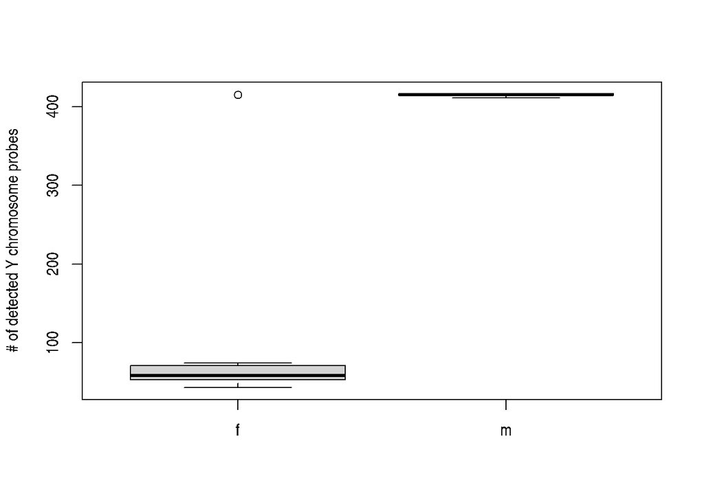

```r
detP = colSums(detP<0.01,na.rm=TRUE)

boxplot(split(detP,pheno$sex),ylab="# of detected Y chromosome probes")
```

```r
split(detP,pheno$sex) %>% sapply(median)
```

```
##     f     m
##  58.5 415.0
```

Almost all of the 416 chromosome probes are called detected in the males whereas among females 60 probes are detected on average.

**QUESTION:** Excluding the Y chromosome and missing probes, what is the percentage of undetected (0.01 cut-off) probes in the first sample. (Use the `table`) function.

### Dye-bias correction

Infinium BeadChips use two fluorescent dyes that are linked to the nucleotides used in the the single-base extension step. A and T nucleotides use are linked with a red dye (the red color channel), G and C nucleotides are linked with a green dye (green color channel). Uncorrected data usually feature higher intensities in the red color channel, the so-called dye bias. For probes of Infinium type II design, which use separate color channels to measure the methylated and unmethylated signal, this results in a shifted distribution of betavalues. (Probes of Infinium design type I are not affected, as they measure both signals in the same color channel.)

`correct_dye_bias()` adjusts the green color channel using the red color channel as reference.

```r
meth %>% dont_normalize                      -> with_bias
meth %>% correct_dye_bias %>% dont_normalize -> corrected
```

Looking at the same loci as before we can check whether dye-bias correction changed the beta values Each probe is of a different type/color channel

```r
meth$manifest$channel[201:203]
```

```
## [1] "Both" "Red"  "Grn"
```

```r
with_bias[201:203,1:3] %>% round(4)
```

```
##            GSM2260480 GSM2260482 GSM2260485
## cg27487046     0.0352     0.0834     0.0361
## cg06091566     0.0753     0.1013     0.1099
## cg03735847     0.0179     0.0247     0.0153
```

```r
corrected[201:203,1:3] %>% round(4)
```

```
##            GSM2260480 GSM2260482 GSM2260485
## cg27487046     0.0196     0.0437     0.0210
## cg06091566     0.0753     0.1013     0.1099
## cg03735847     0.0089     0.0139     0.0069
```

**QUESTION:** Why are the beta values for cg06091566 unchanged? Plotting beta values for heterozygous SNPs, we can observe the dye bias as a deviation from 0.5. For the corrected data, the middle peak aligns with 0.5

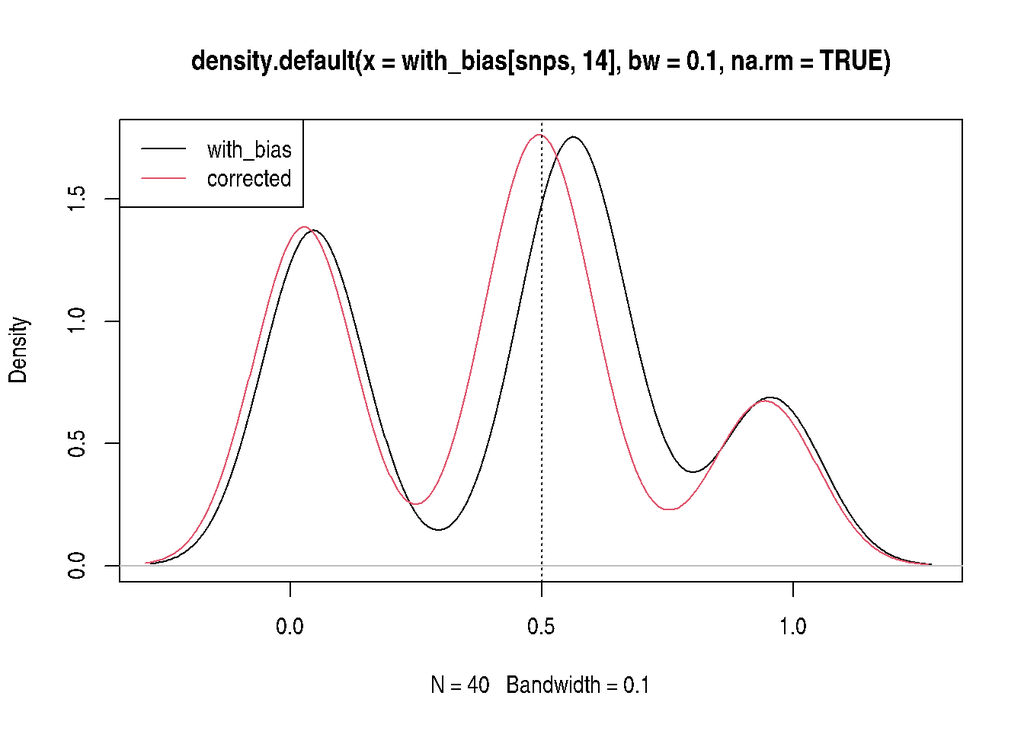

```r
snps = meth$manifest[probe_type=="rs" & channel=="Both"]$index

plot (density(with_bias[snps,14],na.rm=TRUE,bw=0.1),col=1)
lines(density(corrected[snps,14],na.rm=TRUE,bw=0.1),col=2)
abline(v=0.5,lty=3)
legend("topleft",col=1:2,legend=c("with_bias","corrected"),lwd=1)
```

```r
meth %>% correct_dye_bias -> meth
rm(corrected,with_bias)
```

### Sex check

`check_sex()` computes the normalized average total fluorescence intensity of probes targeting the X and Y chromosomes, and `predict_sex()` infers the sex of the sample donors based on this information. This check should be applied after dye-bias correction but before undetected probes are masked.

```r
pheno[,c("X","Y"):=check_sex(meth)]
pheno[,predicted_sex := predict_sex(X,Y,which(sex=="m"),which(sex=="f"))]
```

Are there instances where the sex inferred from the methylation data does not match the information in the recorded meta data?

```r
pheno[sex!=predicted_sex,.(gsm,sex,predicted_sex)]
```

```
##           gsm sex predicted_sex
## 1: GSM2260573   f             m
```

This is indeed the case for the sample with the ID GSM2260573. This most likely means that this sample was mislabeled. We flag this sample for exclusion

```r
pheno[sex!=predicted_sex,exclude:=TRUE]
```

Let’s also plot these data

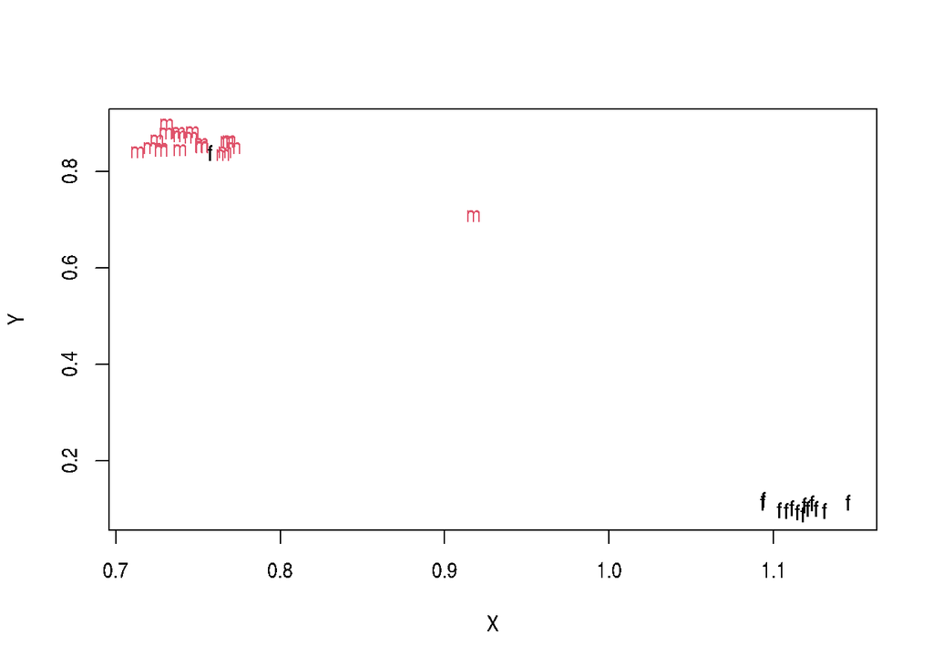

```r
plot(Y~X,data=pheno,type="n")
text(Y~X,labels=sex,col=ifelse(sex=="m",2,1),data=pheno)
```

The mislabeled sample can be easily spotted as it falls into the wrong cluster. **QUESTION:** What is the sample ID of the one outlier in above plot.

Before the next QC steps, we should mask undetected probes. Here we use a cut-off of 0.01

```r
meth = mask(meth,0.01)
```

Now we can compute a “clean” matrix of beta values. Undetected probes are set to NA

```r
beta = dont_normalize(meth)
```

### SNP outliers

`snp_outliers()` returns the average log odds of belonging to the outlier component across all SNP probes. Here a cut-off of -4 is used greater than -4 for exclusion.

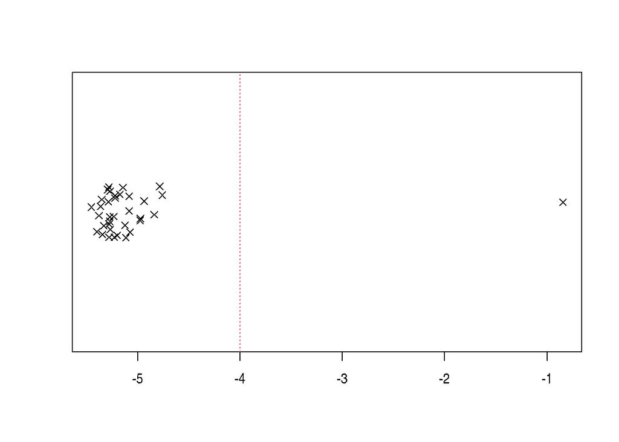

```r
snps = meth$manifest[probe_type=="rs"]$index
genotypes = call_genotypes(beta[snps,],learn=FALSE)
pheno$outlier = snp_outliers(genotypes)

stripchart(pheno$outlier,method="jitter",pch=4)
abline(v=-4,lty="dotted",col=2)
```

**QUESTION:** What is the ID of the sample failing this check? Compare the answer to the answer of the previous question. What can we infer from this?

Mark the failing sample for exclusion

```r
pheno[outlier > -4,exclude:=TRUE]
```

### Check for duplicates

The function `enumerate_sample_donors()` can be used to find samples with the same genetic fingerprint

```r
pheno$donor_id = enumerate_sample_donors(genotypes)
```

Find donor IDs represented more than once

```r
pheno[,n:=.N,by=donor_id]
pheno[n>1,.(gsm,donor_id)]
```

```
##           gsm donor_id
## 1: GSM2260485        3
## 2: GSM2260543        3
```

```r
pheno[gsm=="GSM2260543",exclude:=TRUE] # drop duplicate
```

**QUESTION:** How many different donors are there?

### Principal component analysis

PCA is a popular feature reduction method: it projects high-dimensional data onto a lower-dimensional representation while trying to retain as much variability as possible.

```r
set.seed(292846330)
```

We will apply PCA to the matrix of beta but without the probes targeting the allosomes. Exclude SNP probes as well.

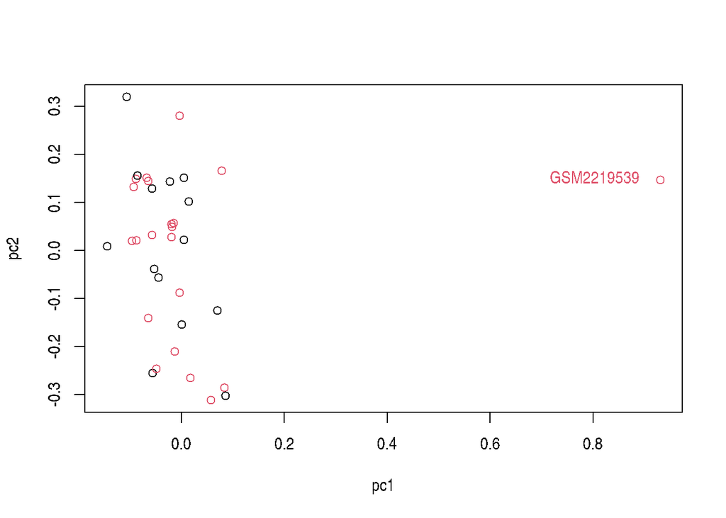

```r
chrXY =  meth$manifest[ chr %in% c("X","Y") | probe_type == "rs"]$index
pcs = beta[-chrXY,]
pcs = pcs - rowMeans(pcs)
pcs = na.omit(pcs)
pcs = t(pcs)
pcs = trlan.svd(pcs,neig=2) # Just the first two principal components
pcs = pcs$u

pheno$pc1 = pcs[,1]
pheno$pc2 = pcs[,2]

plot(pc2~pc1,col=ifelse(sex=="m",2,1),data=pheno)
text(pc2~pc1,labels=pheno[34]$gsm,data=pheno[34],pos=2,offset=1,col=2)
```

GSM2219539 is actually a lung tissue sample from another GEO dataset. It dominates the first principal component and should be excluded as it could drastically change the results of the downstream analysis.

```r
pheno[gsm=="GSM2219539",exclude:=TRUE]
```

PCA may be applied iteratively. After excluding samples that manifest as outliers, repeating PCA can give very different principal components.

### Leukocyte composition

This quality check will only apply in case of blood samples (blood is, however, one of the most commonly studied tissues). The function `estimateLC()` implements the Houseman method (doi.org/10.1186/1471-2105-13-86) to predict the leukocyte composition. The user has the choice between various sets of model parameters trained on various reference datasets (see `?estimateLC` for a list of options). The function operates on the matrix of beta values. we are using the Reinius reference dataset

```r
LC = estimateLC(beta,ref="Reinius")
```

`LC` is a data.table. We can easily add to `pheno`

```r
pheno = cbind(pheno,LC)
```

Plot the proportions of granulocytes versus (the column named `GR`)

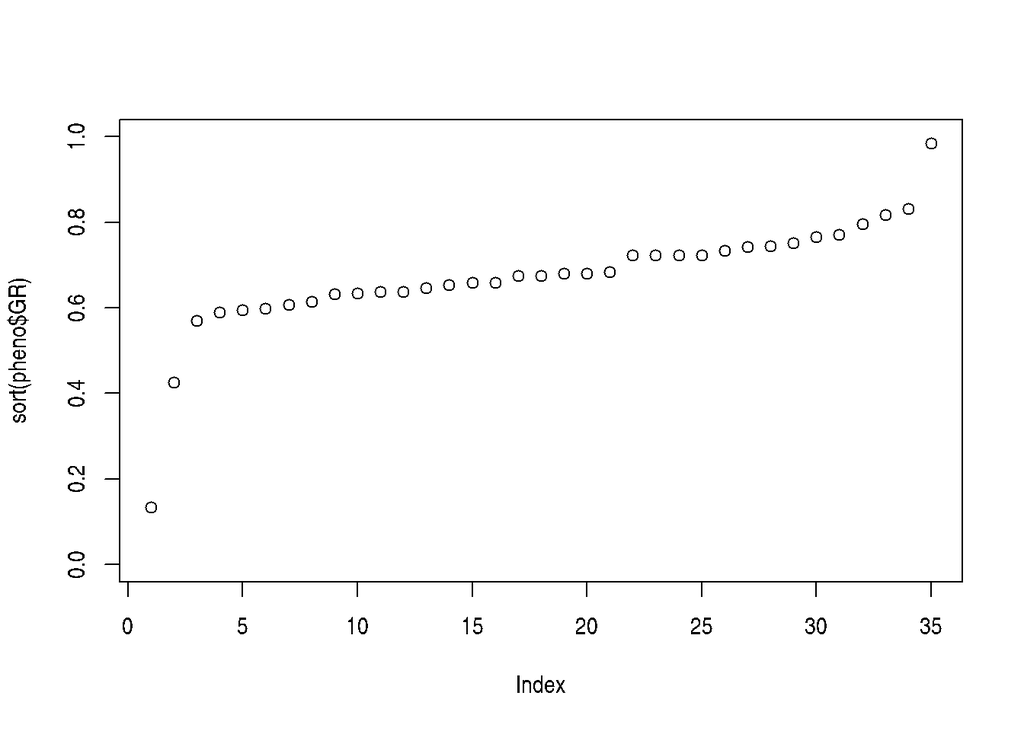

```r
plot(sort(pheno$GR),ylim=c(0,1))
```

We observe two outliers, a sample with a very low proportion of granulocytes, and one with a proportion close to 100%

```r
pheno[which.min(GR),.(gsm,exclude)]
```

```
##           gsm exclude
## 1: GSM2219539    TRUE
```

This is the lung tissue sample from before

```r
pheno[which.max(GR),.(gsm,exclude)]
```

```
##           gsm exclude
## 1: GSM1185585   FALSE
```

This is actually a sample of purified granulocytes. Flag for exclusion.

```r
pheno[gsm=="GSM1185585",exclude:=TRUE]
```

Let’s confirm that the leukocyte composition is a confounded with smoking status LC stratified by smoking status

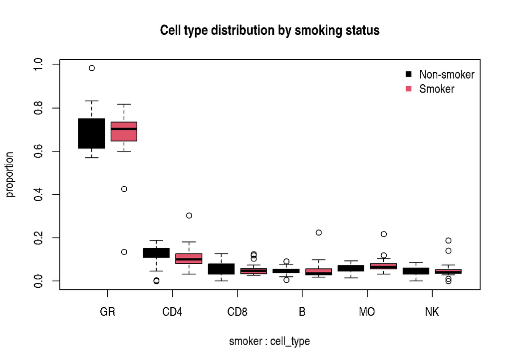

```r
LC$smoker = pheno$smoker
LC = melt(LC,value.name="proportion",variable.name="cell_type",id.vars="smoker")

boxplot(proportion ~ smoker+cell_type,LC,col=1:2,
    main="Cell type distribution by smoking status",xaxt="n")
axis(1,at=seq(from=1.5, to=11.5,by=2),adj=1,labels=unique(LC$cell_type))
legend("topright",c("Non-smoker","Smoker"),pch=15,bty='n',col=1:2)
```

### Clean up

Keep only samples that passed all quality checks

```r
keep = which(!pheno$exclude)
pheno = pheno[keep]
beta  = beta[,keep]
```

Keep only the columns relevant for downstream analysis

```r
pheno = pheno[,.(gsm,smoker,sex,CD4,CD8,NK,MO,GR,B)]
```

Also keep a copy of the manfist

```r
manifest = copy(meth$manifest)
```

Write data to disk. (Do not acutally run the next line. Only when running the script locally, you should un-comment the next line in order to save the results to be re-used in the following scripts).

```r
save(pheno,manifest,beta,file="data/processed.rda")
```